# PeLiCa: A Web Application for Efficient Analysis of Peptide Libraries

Eric Hare, Timo Sieber, Heike Hofmann  
August 3rd, 2014

### What is a peptide?

- **Peptides** are chains of two or more **amino acids**
- **Amino acids** are chains of exactly three **bases** (Adenine, Cytosine, Guanine, and Thymine/Uracil)

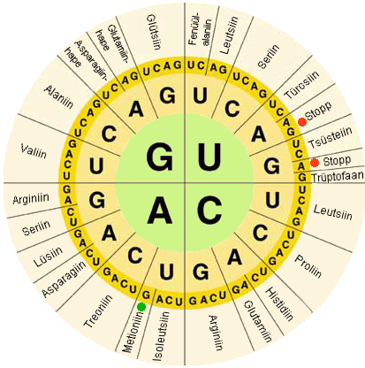

### What is a peptide library?

A peptide library is a large collection of peptides which are synthesized with a systematic combination of amino acids.

They are used in the study of:

- Drug design
- Protein interaction
- Identifying important cells

### The Problem

Peptide libraries are large, often containing 100 million or more peptides.

The more peptides in the library, the more useful, but also the more expensive.

Little work has been done to analyze the statistical properties of these libraries - How many of the 100 million are duplicates, and how many potential peptides are the libraries missing?

### PeLiCa

PeLiCa (or Peptide Library Calculator) is an easy-to-use web-based tool (Shiny application) for analyzing the statistical properties of peptide libraries.

http://www.pelica.org

[figure not shown]

### Features

- Computes statistical properties of a number of common library schemes and sizes:
  - **Coverage**: “What percentage of all possible peptides are included in my library?”
  - **Efficiency**: “What is the ratio of the expected number of different peptides included to the overall size of my library?”
  - **Inclusion**: “What are the chances of including a particular peptide of interest in the library?”
  - **Library Schemes** “Which encoding scheme is most suitable/least expensive for the goals of my study?”
- Clean, easy-to-use UI designed for biologists without R experience

### Features (Continued)

- Web-based, written in Shiny, to eliminate need for software installation, and provide the greatest platform compatibility - Just a modern web browser needed
- Helpful progress dialogs during more intensive computations
- Consistent help/documentation system integrated throughout the application

### Computational Issues

Ideally, we could sample peptides and compute empirical coverage probabilities and library efficiency… But libraries may include upwards of 10<sup>15</sup> peptides.

Instead, we derive an approximation to the expected number of different peptides as:

\( b_i = \) number of peptides theoretically possible in peptide class i

\( N = \) size of the library (number of peptides)

\( p_i = \) probability (size) of peptide class i

\( D(N, k) = \sum_{i=1}^{v^k}b_i(1 - e^{-Np_i/b_i}) \)

### Computational Issues (Continued)

From this, all derivations are possible:

\( c = \) number of amino acids

\( k = \) length of each peptide

Coverage \( = \) Diversity \( /c^k \)

Efficiency \( = \) Diversity \( /N \)

### Live Demo

URL is http://www.pelica.org

### Conclusion

- PeLiCa is an attempt to use Shiny to broaden the reach of statistical computations in R to biologists without programming experience
- Web applications offer a greater level of support, flexibility, and ease of use
- Other features not discussed - Neighborhoods, diversity, fully customized library schemes

### Thank You

Eric Hare (erichare@iastate.edu)

Any Questions?